# Assignment 3 - Diamonds Price Estimation

Ecemnaz Bay

9/4/2020

## 0.1 Diamonds Price Estimation

That assignment aims to find a prediction model for estimating the price of a diamond given its properties.  
`rDiamonds` data set in `rggplot2` package is used for the assignment.

Training and test data sets are created.

```r
set.seed(503)
diamonds_test <- diamonds %>% mutate(diamond_id = row_number()) %>%
    group_by(cut, color, clarity) %>% sample_frac(0.2) %>% ungroup()

diamonds_train <- anti_join(diamonds %>% mutate(diamond_id = row_number()),
    diamonds_test, by = "diamond_id")

diamonds_all <- bind_rows(diamonds_train,diamonds_test)
```

Below is a sample from train data set.

```r
  head(diamonds_train)%>%
  kbl(caption = "Sample from Training Data") %>%
  kable_minimal(full_width = F)
```

Sample from Training Data

| carat | cut | color | clarity | depth | table | price | x | y | z | diamond_id |
| --- | --- | --- | --- | --- | --- | --- | --- | --- | --- | --- |
| 0.21 | Premium | E | SI1 | 59.8 | 61 | 326 | 3.89 | 3.84 | 2.31 | 2 |
| 0.23 | Good | E | VS1 | 56.9 | 65 | 327 | 4.05 | 4.07 | 2.31 | 3 |
| 0.29 | Premium | I | VS2 | 62.4 | 58 | 334 | 4.20 | 4.23 | 2.63 | 4 |
| 0.31 | Good | J | SI2 | 63.3 | 58 | 335 | 4.34 | 4.35 | 2.75 | 5 |
| 0.24 | Very Good | I | VVS1 | 62.3 | 57 | 336 | 3.95 | 3.98 | 2.47 | 7 |
| 0.26 | Very Good | H | SI1 | 61.9 | 55 | 337 | 4.07 | 4.11 | 2.53 | 8 |

Below is a sample from test data set.

```r
  head(diamonds_test)%>%
  kbl(caption = "Sample from Test Data") %>%
  kable_minimal(full_width = F)
```

Sample from Test Data

| carat | cut | color | clarity | depth | table | price | x | y | z | diamond_id |
| --- | --- | --- | --- | --- | --- | --- | --- | --- | --- | --- |
| 1.70 | Fair | D | I1 | 64.7 | 56 | 5617 | 7.46 | 7.37 | 4.80 | 13776 |
| 0.58 | Fair | D | SI2 | 65.1 | 58 | 1156 | 5.25 | 5.22 | 3.41 | 40690 |
| 1.00 | Fair | D | SI2 | 65.6 | 66 | 3767 | 6.10 | 6.01 | 3.97 | 5152 |
| 1.05 | Fair | D | SI2 | 65.4 | 59 | 3816 | 6.30 | 6.24 | 4.10 | 5359 |
| 0.70 | Fair | D | SI2 | 64.5 | 60 | 2167 | 5.53 | 5.47 | 3.55 | 49828 |
| 0.90 | Fair | D | SI2 | 64.6 | 59 | 3847 | 6.04 | 6.01 | 3.89 | 5510 |

### 0.1.1 Correlations Plot

In order to have a clear visualization, a function is used to plot the correlations. (Source can be seen in references section.)

- Converts all non-numeric variables into numeric ones.
- Drops duplicates and perfect correlations (correlations with itself).
- Set up the data frame sorted by the highest correlation first to see the raw correlations in a table.

Here, the function is changed to include perfect correlations and duplicates.  
Moreover, it is set to show variables only have a specific significance level above a threshold.  
That threshold is set to 0.05 as the initial default.

```
##        Var1    Var2        Freq
## 1     carat   carat  1.00000000
## 12      cut     cut  1.00000000
## 23    color   color  1.00000000
## 34  clarity clarity  1.00000000
## 45    depth   depth  1.00000000
## 56    table   table  1.00000000
## 67    price   price  1.00000000
## 78        x       x  1.00000000
## 89        y       y  1.00000000
## 100       z       z  1.00000000
## 8         x   carat  0.97509423
## 71    carat       x  0.97509423
## 79        y       x  0.97470148
## 88        x       y  0.97470148
```

[output cut: 70 more lines]

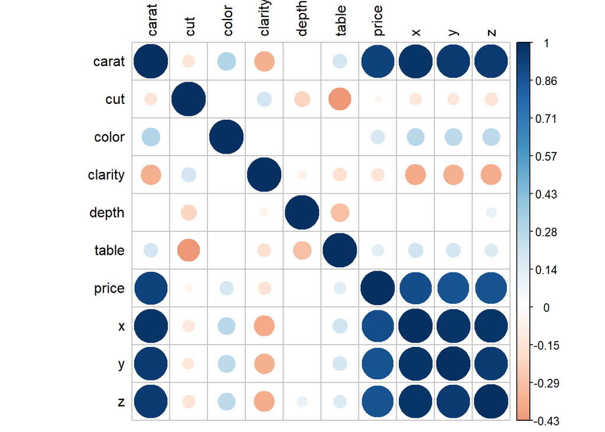

```r
diamonds_AllForCorr <- select(diamonds_all, -diamond_id)

corr_simple <- function(data=diamonds_AllForCorr,sig=0.05){
  #convert data to numeric in order to run correlations
  #convert to factor first to keep the integrity of the data - each value will become a number rather than turn into NA
  df_cor <- data %>% mutate_if(is.character, as.factor)
  df_cor <- df_cor %>% mutate_if(is.factor, as.numeric)
  #run a correlation and drop the insignificant ones
  corr <- cor(df_cor)
    #prepare to drop duplicates and correlations of 1
    #corr[lower.tri(corr,diag=TRUE)] <- NA
    #drop perfect correlations
    #corr[corr == 1] <- NA
  #turn into a 3-column table
  corr <- as.data.frame(as.table(corr))
  #remove the NA values from above
  corr <- na.omit(corr)
  #select significant values
  corr <- subset(corr, abs(Freq) > sig)
  #sort by highest correlation
  corr <- corr[order(-abs(corr$Freq)),]
  #print table
  print(corr)
  #turn corr back into matrix in order to plot with corrplot
  mtx_corr <- reshape2::acast(corr, Var1~Var2, value.var="Freq")

  #plot correlations visually
  corrplot(mtx_corr, is.corr=FALSE, tl.col="black", na.label=" ")
}
corr_simple()
```

Structure of variables that has correlation with price with a significance level over 0.05 is as follows :

- Price is a continuous response variable
- x is a continuous explanatory variable
- y is a continuous explanatory variable
- z is a continuous explanatory variable
- Carat is a continuous explanatory variable
- Color is an ordered factor type of explanatory variable with 7 different levels.
- Table is a continuous explanatory variable
- Clarity is an ordered factor type of explanatory variable with 8 different levels.
- Cut is an ordered factor type of explanatory variable with 5 different levels.

```r
str(diamonds_all)
```

```
## tibble [53,940 x 11] (S3: tbl_df/tbl/data.frame)
##  $ carat     : num [1:53940] 0.21 0.23 0.29 0.31 0.24 0.26 0.22 0.23 0.3 0.23 ...
##  $ cut       : Ord.factor w/ 5 levels "Fair"<"Good"<..: 4 2 4 2 3 3 1 3 2 5 ...
##  $ color     : Ord.factor w/ 7 levels "D"<"E"<"F"<"G"<..: 2 2 6 7 6 5 2 5 7 7 ...
##  $ clarity   : Ord.factor w/ 8 levels "I1"<"SI2"<"SI1"<..: 3 5 4 2 7 3 4 5 3 5 ...
##  $ depth     : num [1:53940] 59.8 56.9 62.4 63.3 62.3 61.9 65.1 59.4 64 62.8 ...
##  $ table     : num [1:53940] 61 65 58 58 57 55 61 61 55 56 ...
##  $ price     : int [1:53940] 326 327 334 335 336 337 337 338 339 340 ...
##  $ x         : num [1:53940] 3.89 4.05 4.2 4.34 3.95 4.07 3.87 4 4.25 3.93 ...
##  $ y         : num [1:53940] 3.84 4.07 4.23 4.35 3.98 4.11 3.78 4.05 4.28 3.9 ...
##  $ z         : num [1:53940] 2.31 2.31 2.63 2.75 2.47 2.53 2.49 2.39 2.73 2.46 ...
##  $ diamond_id: int [1:53940] 2 3 4 5 7 8 9 10 11 12 ...
```

Upon correlation table, darker blue and bigger circles denotes higher correlation.  
Thus, 4 variables are selected to build the model:

- x
- y
- z
- Carat

In order to understand distribution of the response variable, price, density plots are used.  
In the below figure, density plots of overall data, test and train sets are combined together.

Response variable seems to follow a continuous probability distribution. Price has a sharp lower bound value of zero (always positive) but no sharp upper bound can be defined.  
As seen in density plots, the tail on the right hand side is longer, so a positive skewness is observed.  
Gamma distributions can be used according to these observations.

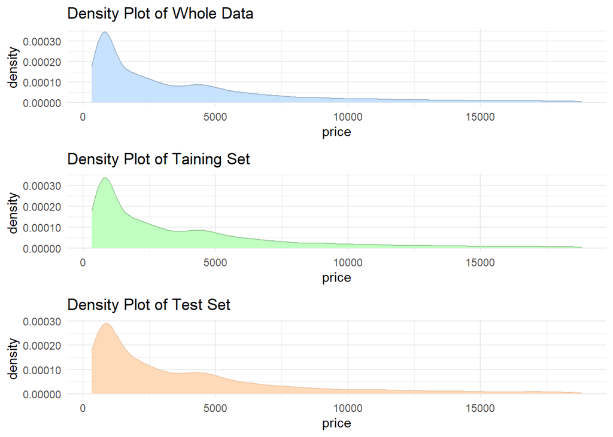

```r
alldata <- ggplot(diamonds_all, aes(x=price))+
  geom_density(color="slategray3", fill="slategray1")+
  theme_minimal()+
  ggtitle("Density Plot of Whole Data")+
  scale_y_continuous(labels = comma)


traindata <- ggplot(diamonds_train, aes(x=price))+
  geom_density(color="darkseagreen3", fill="darkseagreen1")+
  theme_minimal()+
  ggtitle("Density Plot of Taining Set")+
  scale_y_continuous(labels = comma)



testdata <- ggplot(diamonds_test, aes(x=price))+
  geom_density(color="peachpuff2", fill="peachpuff")+
  theme_minimal()+
  ggtitle("Density Plot of Test Set")+
  scale_y_continuous(labels = comma)


ggarrange(alldata, traindata, testdata, ncol = 1, nrow = 3)
```

### 0.1.2 Evaluating Models

A base model is built including all explanatory variables selected via correlation plot.  
Backward regression is applied to find out the best possible model.

```r
diamonds_train_forGamma <- na.omit(diamonds_train)
diamonds_test_forGamma <- na.omit(diamonds_test)

Model_1 <- glm(price~x+y+z+carat,family = Gamma,
        data=diamonds_train_forGamma,
        start=c(0.5,0.5,0.5,0.5,0.5))

summary(Model_1)
```

```
##
## Call:
## glm(formula = price ~ x + y + z + carat, family = Gamma, data = diamonds_train_forGamma,
##     start = c(0.5, 0.5, 0.5, 0.5, 0.5))
##
## Deviance Residuals:
##     Min       1Q   Median       3Q      Max
##  -1.609   27.789   37.925   47.602  185.614
##
## Coefficients:
##              Estimate Std. Error t value Pr(>|t|)
## (Intercept)  0.997131   6.301847   0.158    0.874
## x           -0.123070   0.677494  -0.182    0.856
## y           -0.001192   0.079861  -0.015    0.988
## z           -0.012507   1.163875  -0.011    0.991
## carat        0.084792   1.134872   0.075    0.940
##
## (Dispersion parameter for Gamma family taken to be 929969)
##
##     Null deviance:    42391  on 43142  degrees of freedom
## Residual deviance: 71665391  on 43138  degrees of freedom
## AIC: 1355333
##
## Number of Fisher Scoring iterations: 25
```

The least significant variable, z is eliminated from th emodel. New model shows imrovement according to AIC.

```r
Model_2 <- glm(price~x+y+carat,family = Gamma,
        data=diamonds_train_forGamma,
        start=c(0.5,0.5,0.5,0.5))

summary(Model_2)
```

```
##
## Call:
## glm(formula = price ~ x + y + carat, family = Gamma, data = diamonds_train_forGamma,
##     start = c(0.5, 0.5, 0.5, 0.5))
##
## Deviance Residuals:
##    Min      1Q  Median      3Q     Max
## -2.459   6.701   9.499  12.187  47.485
##
## Coefficients:
##               Estimate Std. Error t value Pr(>|t|)
## (Intercept)  0.0661368  0.0217451   3.041  0.00236 **
## x           -0.0084667  0.0027822  -3.043  0.00234 **
## y           -0.0001106  0.0003123  -0.354  0.72312
## carat        0.0052078  0.0017105   3.045  0.00233 **
## ---
## Signif. codes:  0 '***' 0.001 '**' 0.01 '*' 0.05 '.' 0.1 ' ' 1
##
## (Dispersion parameter for Gamma family taken to be 17.1283)
##
##     Null deviance:   42391  on 43142  degrees of freedom
## Residual deviance: 4605070  on 43139  degrees of freedom
## AIC: 1122205
##
## Number of Fisher Scoring iterations: 25
```

The least significant variable, y is eliminated from the model. New model shows imrovement according to AIC.

In Model_3 all explanatory variables have significant effect on the price with a significance level of 0.05.

```r
Model_3 <- glm(price~x+carat,family = Gamma,
        data=diamonds_train_forGamma,
        start=c(0.5,0.5,0.5))

summary(Model_3)
```

```
##
## Call:
## glm(formula = price ~ x + carat, family = Gamma, data = diamonds_train_forGamma,
##     start = c(0.5, 0.5, 0.5))
##
## Deviance Residuals:
##     Min       1Q   Median       3Q      Max
## -3.5868  -0.7725  -0.2709   0.1667   5.5165
##
## Coefficients:
##               Estimate Std. Error t value Pr(>|t|)
## (Intercept)  1.088e-03  2.971e-06   366.2   <2e-16 ***
## x           -1.493e-04  4.145e-07  -360.2   <2e-16 ***
## carat        1.118e-04  3.752e-07   297.9   <2e-16 ***
## ---
## Signif. codes:  0 '***' 0.001 '**' 0.01 '*' 0.05 '.' 0.1 ' ' 1
##
## (Dispersion parameter for Gamma family taken to be 0.5907617)
##
##     Null deviance: 42391  on 43142  degrees of freedom
## Residual deviance: 17671  on 43140  degrees of freedom
## AIC: 758803
##
## Number of Fisher Scoring iterations: 25
```

Different link functions of Gamma are compared according to their AIC values.  
Identity link function is selected with the lowest AIC value.  
AIC of identity, inverse and log link functions are calculated respectively as follows :

```r
for(link in c("identity","inverse","log")){
  GlmModel = glm(price~x+carat,
                 family = Gamma(link=link),
                 data=diamonds_train_forGamma,
                 start=c(0.5,0.5,0.5))
  print(AIC(GlmModel))
  }
```

```
## [1] 696939.9
## [1] 758803.1
## [1] 1074032
```

Here is the summary of final model :

```r
FinalModel <- glm(price~x+carat,family = Gamma(link="identity"),
                  data=diamonds_train_forGamma,
                  start=c(0.5,0.5,0.5))

summary(FinalModel)
```

```
##
## Call:
## glm(formula = price ~ x + carat, family = Gamma(link = "identity"),
##     data = diamonds_train_forGamma, start = c(0.5, 0.5, 0.5))
##
## Deviance Residuals:
##      Min        1Q    Median        3Q       Max
## -1.11278  -0.24172  -0.06862   0.15353   1.94617
##
## Coefficients:
##             Estimate Std. Error t value Pr(>|t|)
## (Intercept) -944.147      7.698 -122.65   <2e-16 ***
## x            -41.138      1.431  -28.75   <2e-16 ***
## carat       5934.790     14.336  413.98   <2e-16 ***
## ---
## Signif. codes:  0 '***' 0.001 '**' 0.01 '*' 0.05 '.' 0.1 ' ' 1
##
## (Dispersion parameter for Gamma family taken to be 0.1116708)
##
##     Null deviance: 42390.6  on 43142  degrees of freedom
## Residual deviance:  4431.9  on 43140  degrees of freedom
## AIC: 696940
##
## Number of Fisher Scoring iterations: 25
```

### 0.1.3 RMSE Calculation

In order to get insight about prediction performance, RMSE is calculated.

```r
   pred_TrainData = predict(FinalModel)
   pred_TestData =  predict(FinalModel,new=diamonds_test_forGamma)

   rmse(diamonds_test_forGamma$price, pred_TestData)
```

```
## [1] 1815.901
```

### 0.1.4 Residual Plot

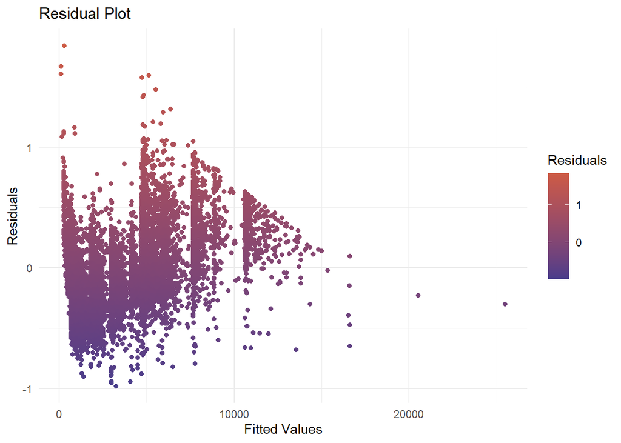

```r
FinalModel_TestData <- glm(price~x+carat,family = Gamma(link="identity"),
                  data=diamonds_test_forGamma,
                  start=c(0.5,0.5,0.5))

ggplot(FinalModel_TestData) +
  geom_point(aes(x=.fitted, y=.resid, col=.resid)) +
  theme_minimal() +
  ggtitle("Residual Plot") +
  labs(x = "Fitted Values",
       y = "Residuals") +
  scale_color_gradient(low="darkslateblue", high="coral3") +
  labs(col = "Residuals")
```

### 0.1.5 References

- https://towardsdatascience.com/how-to-create-a-correlation-matrix-with-too-many-variables-309cc0c0a57
- http://people.stat.sfu.ca/~raltman/stat402/402L26.pdf
- https://www.mygreatlearning.com/blog/gamma-distribution/
- https://wiki.analytica.com/index.php?title=Gamma_distribution
- https://codeburst.io/2-important-statistics-terms-you-need-to-know-in-data-science-skewness-and-kurtosis-388fef94eeaa
- https://stat.ethz.ch/pipermail/r-help/2009-December/416122.html
- https://www.rdocumentation.org/packages/Metrics/versions/0.1.4/topics/rmse
- https://cran.r-project.org/web/packages/Metrics/Metrics.pdf
- https://stackoverflow.com/questions/36731027/how-can-i-plot-the-residuals-of-lm-with-ggplot